# Chapter 3: Timer Series Decomposition

> *Decomposition definition - A time series is of composed of 3 components: trend, seasonality, and the remainder. Decomposition breaks a time series down into its 3 component parts for further study.*

## 3.1 Transformations and Adjustments

#### 4 Types

1. **Calendar Adjustments**
   1. Some variation in seasonal data may be due to calendar effects (i.e. some months have fewer days than others and potentially lower sales)
   2. a potential solution to the above would be to compute avg sales per day in each month.
2. **Population Adjustments**
   1. Data affected by population changes should likely be adjusted to give per-capita data.
   2. Problem: studying amt of hospital beds in a certain region over time. Consider number of beds per 1000 ppl to adjust for population changes in the region.

**Example:**

A common transformation of GDP is GDP per-capita

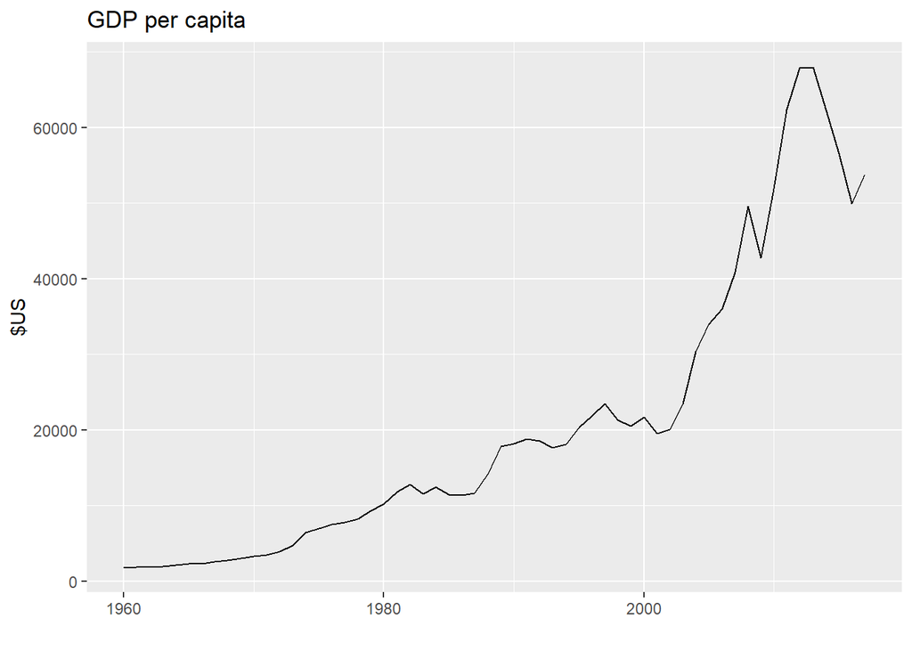

```r
global_economy %>%
  filter(Country == 'Australia') %>%
  autoplot(GDP/Population) +
  labs(title= 'GDP per capita', y='$US', x='')
```

3. **Inflation Adjustments**

The value of money changes over time, and data associated with currency value should be adjusted for the inflation of that currency. (i.e. historical house price data should be in context of the most recent time period in the data, or in today’s dollars).

To make such adjustments, a price index is used.

**Example:** Looking at aggregate annual “newspaper and book” retail turnover from `aus_retail` and adjusting the data for inflation using Consumer Price Index (CPI) from `global_economy` allow us to see the changes over time.

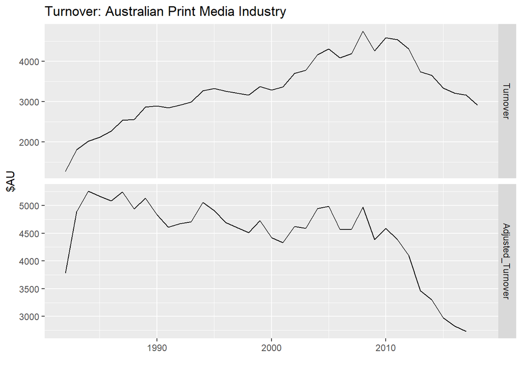

```r
print_retail <- aus_retail %>%
  filter(Industry == "Newspaper and book retailing") %>%
  group_by(Industry) %>%
  index_by(Year = year(Month)) %>%
  summarize(Turnover = sum(Turnover))

aus_economy <- global_economy %>%
  filter(Code == 'AUS')

print_retail %>%
  left_join(aus_economy, by = "Year")%>%
  mutate(Adjusted_Turnover = Turnover / CPI * 100) %>%
  pivot_longer(c(Turnover, Adjusted_Turnover),
               values_to = 'Turnover') %>%
  mutate(name = factor(name,
                       levels = c("Turnover", "Adjusted_Turnover"))) %>%
  ggplot(aes(x=Year, y=Turnover)) +
  geom_line() +
  facet_grid(name ~ ., scales = 'free_y')+
  labs(title = "Turnover: Australian Print Media Industry",
       y = '$AU',
       x='')
```

Above we can see that Australia’s print industry has been in decline for much longer than the original time series would suggest.

4. **Mathematical Transformations**

Helpful when a time series has variations that increase or decrease with the level of the series.

- log transformations
- power transformations
- Box Cox transformations - a combination of the above two methods which depends on the parameter $\lambda$
  - A good value of $\lambda$ is one which makes the size of the seasonal variation about the same across the entire series
  - The `guerrero` feature can be used to choose a value of lambda for you.

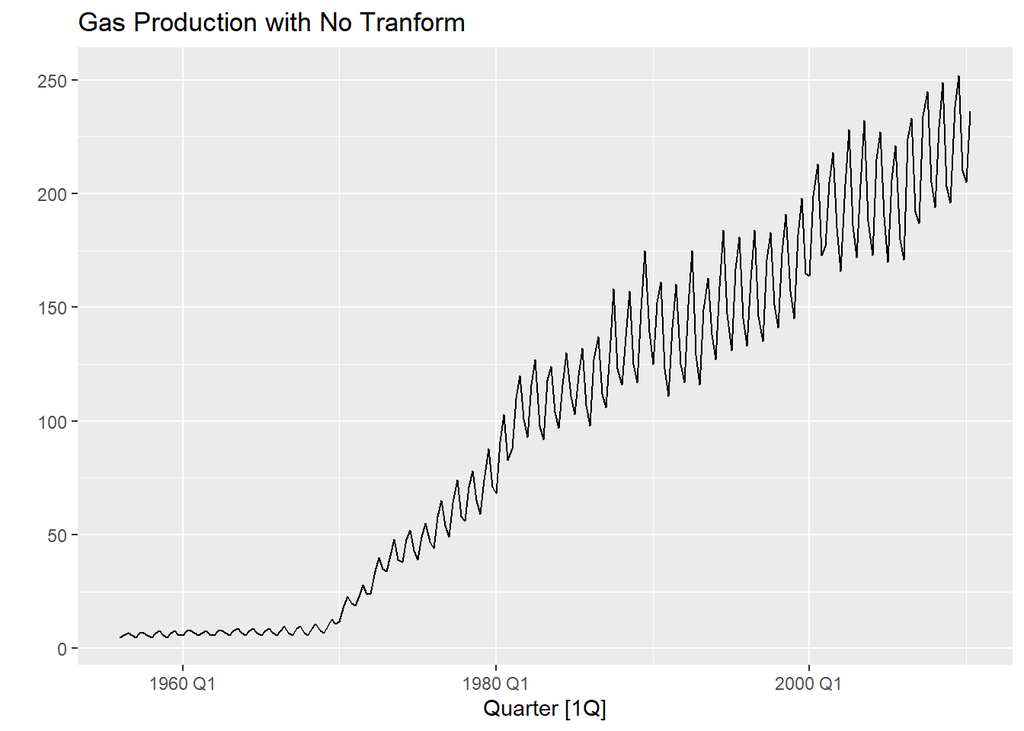

```r
autoplot(aus_production, Gas)+
  labs(y='',
       title='Gas Production with No Tranform')
```

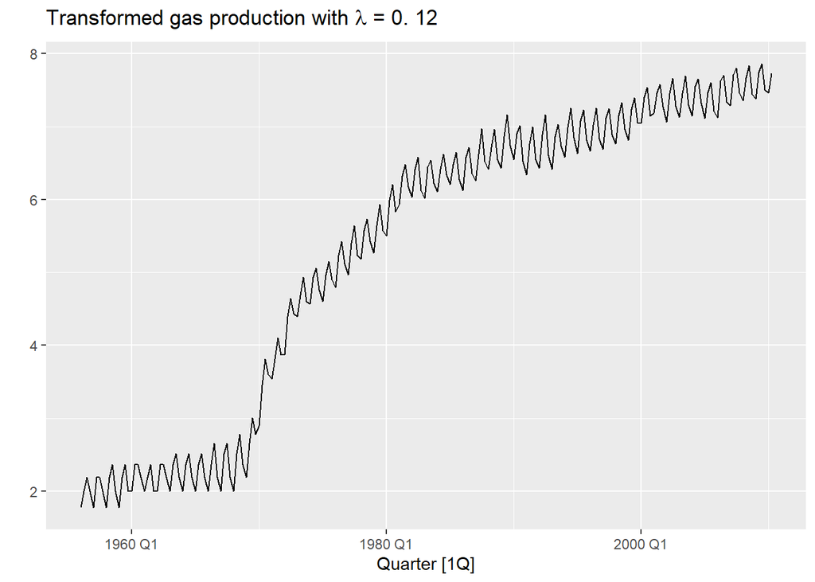

```r
lambda <- aus_production %>%
  features(Gas, features = guerrero) %>%
  pull(lambda_guerrero)
aus_production %>%
  autoplot(box_cox(Gas, lambda)) +
  labs(y = "",
       title = latex2exp::TeX(paste0(
         "Transformed gas production with $\\lambda$ = ",
         round(lambda,2))))
```

Above we can see the variance of seasonal ups and downs has been transformed to a consistent variation.

## 3.2 Time Series Components

**Two Types of Decomposition:**

1. **Additive**

$$y_t= S_t + T_t + R_t$$

Where $y_t$ is the data, $S_t$ is the seasonal component, $T_t$ is the trend, and $R_t$ is the remainder

Most appropriate if the magnitude of the seasonal fluctuations or varation of the trend cycle does not vary with the level of the time series.

2. **Mutliplicative**

$$y_t = S_t * T_t * R_t$$

Most appropriate when the variation in the seasonal pattern appears to be proportional to the level of the time series (i.e. very common with economic data)

An alternative to using a multiplicative series is to transform the data (like via Box-Cox in 3.1) until varation is steady over time, then use additive decomposition.

$\log y_t = \log S_t + \log T_t + \log R_t$ is equivalent to the multiplicative equation

**Example:**

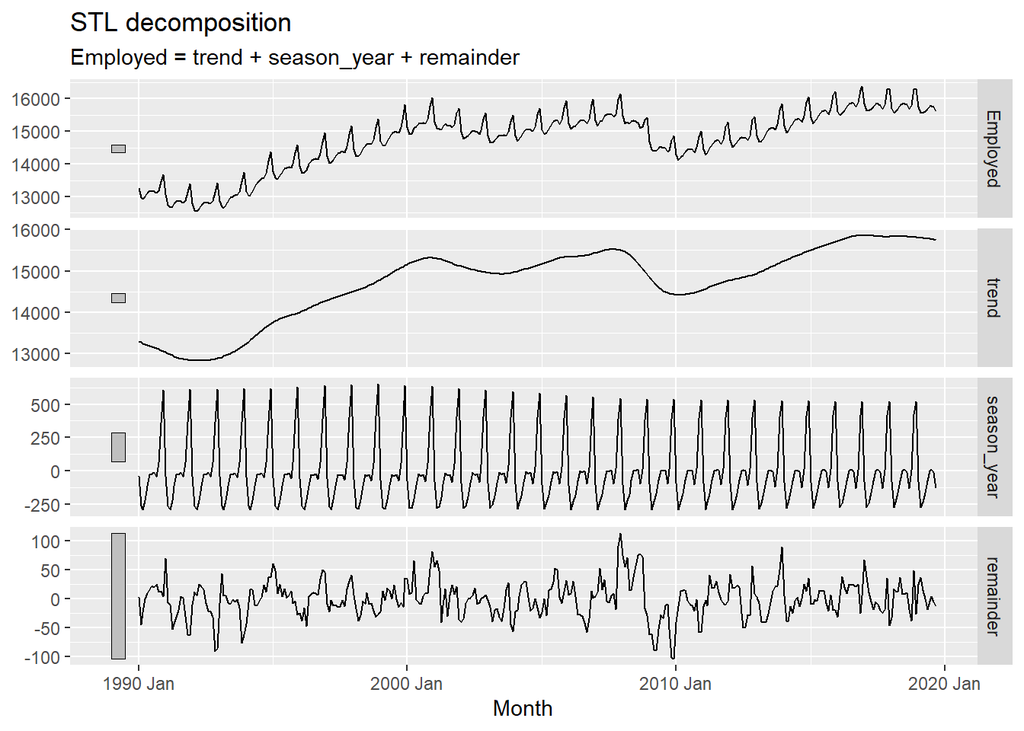

```r
us_retail_employment <- us_employment %>%
  filter(year(Month) >= 1990, Title == 'Retail Trade') %>%
  select(-Series_ID)

dcmp <- us_retail_employment %>%
  model(stl = STL(Employed))

autoplot(components(dcmp))
```

Trend, Seasonality and the Remainder (White noise) are shown in the bottom three panels. The gray boxes on the left of each series show the relative scale of each one of the components as each box is the same size. The large size of the box for the remainder component shows that its variation is actually the smallest of the three.

#### **Seasonally Adjusted Data**

*definition*: the resulting data from when the seasonal component is removed from the original time series

Situations where seasonality is not of primary interest:

- Monthly employment data are usually seasonally adjusted in order to highlight variation of the underlying state of the economy rather than the seasonal variation.
- An increase in unemployment do to people leaving school seeking work is seasonal variation while an increase in unemployment due to recession is not.

**Example**

Below shows the seasonal data subtracted from the original series

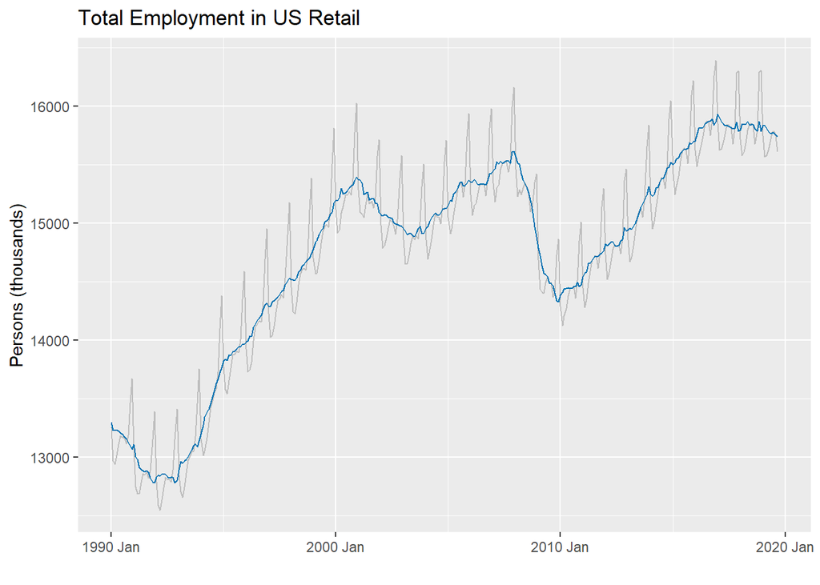

```r
components(dcmp) %>%
  as_tsibble() %>%
  autoplot(Employed, color = 'gray') +
  geom_line(aes(y=season_adjust), color = '#0072B2') +
  labs(y='Persons (thousands)',
       x='',
       title='Total Employment in US Retail')
```

## 3.3 Moving Averages

Moving averages are the foundation of estimating the trend portion of decomposition using the following equation:

$$\hat{T_t} = \frac{1}{m}\sum_{j=-k}^{k}y_t+j$$

where $m = 2k+1$. The estimate of the trend-cycle at time $t$ is obtained by averaging values of the time series within $k$ periods of $t$. The average eliminates some of the randomness in the data. This is termed “$m$-MA”, a moving average (MA) of order $m$.

**Example**

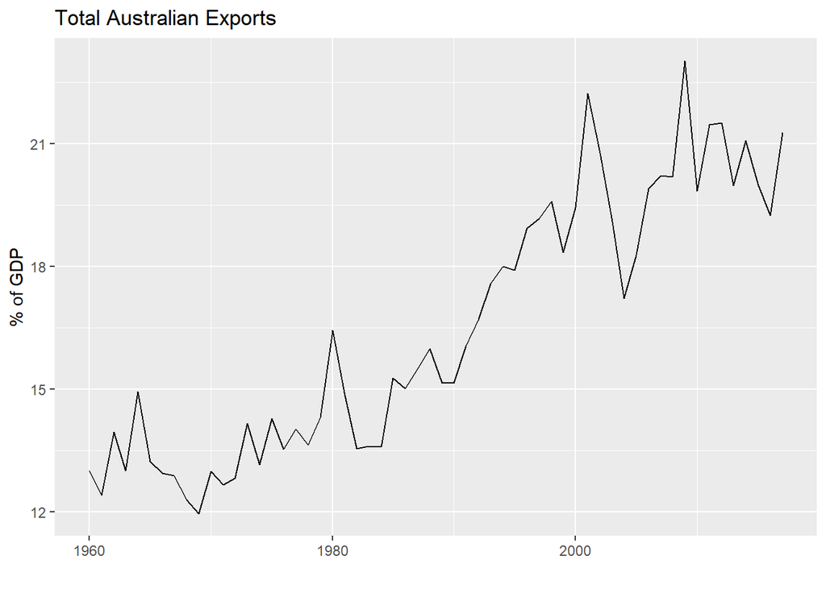

```r
global_economy %>%
  filter(Country == 'Australia') %>%
  autoplot(Exports) +
  labs(y='% of GDP',
       x='',
       title='Total Australian Exports')
```

To compute the moving average we would do the following:

```r
aus_exports <- global_economy %>%
  filter(Country == 'Australia') %>%
  mutate(
    `5-MA` = slider::slide_dbl(Exports, mean, .before=2, .after=2, .complete=TRUE)
  )
```

Then we plot the original and the MA

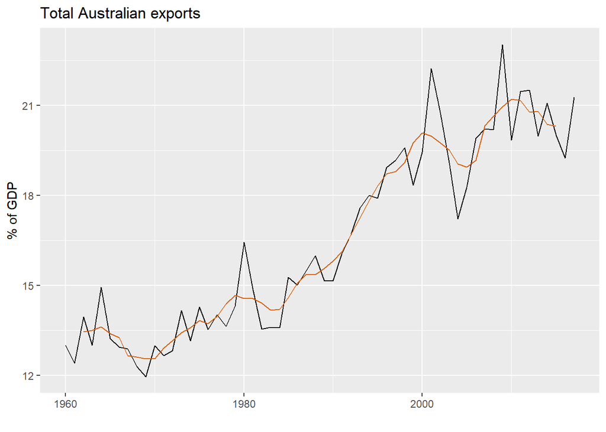

```r
aus_exports %>%
  autoplot(Exports) +
  geom_line(aes(y = `5-MA`), colour = "#D55E00") +
  labs(y = "% of GDP",
       x='',
       title = "Total Australian exports") +
  guides(colour = guide_legend(title = "series"))
```

(Personal note here: coming form Python, it is unclear to me why the moving average is calculated based on observations before and after the the current observation. In Python and in finance, rolling averages are typically calculated only from preceding observations. This can obviously be adjusted in the `.before` and `.after` arguments above, but it is unclear why a centered MA is being taught.)

Also note, you can take moving averages of moving averages:

```r
beer <- aus_production %>%
  filter(year(Quarter) >= 1992) %>%
  select(Quarter, Beer)
beer_ma <- beer %>%
  mutate(
    `4-MA` = slider::slide_dbl(Beer, mean,
                .before = 1, .after = 2, .complete = TRUE),
    `2x4-MA` = slider::slide_dbl(`4-MA`, mean,
                .before = 1, .after = 0, .complete = TRUE)
  )

beer_ma
```

```
## # A tsibble: 74 x 4 [1Q]
##    Quarter  Beer `4-MA` `2x4-MA`
##      <qtr> <dbl>  <dbl>    <dbl>
##  1 1992 Q1   443    NA       NA
##  2 1992 Q2   410   451.      NA
##  3 1992 Q3   420   449.     450
##  4 1992 Q4   532   452.     450.
##  5 1993 Q1   433   449      450.
##  6 1993 Q2   421   444      446.
##  7 1993 Q3   410   448      446
##  8 1993 Q4   512   438      443
##  9 1994 Q1   449   441.     440.
## 10 1994 Q2   381   446      444.
## # ... with 64 more rows
```

**Weighted Moving Averages**

Combinations of moving averages (like the 2x4 above) result in weighted moving averages.

A major advantage of the weighted moving average is they yield a smoother estimate, also, if the MA is not centered, the later observations would have greater weight and thus more influence on forecasts.

## 3.4 Classical Decomposition

The last paragraph says “While classical decomposition is still widely used, it is not recommended as there are now several much better methods.” So I will move on.

## 3.5 Decomp Methods Used by Stats Agencies

**2 Most Popular Methods**

1. X-11
   1. Originated with US Census Bureau
   2. Based on classical decomp but contains extra features:
      1. trend-cycle estimates for end points
      2. seasonal component allowed to vary over time
      3. handles trading day variation and holidays
      4. Methods for both additive and multiplicative decomp
      5. robust to outliers

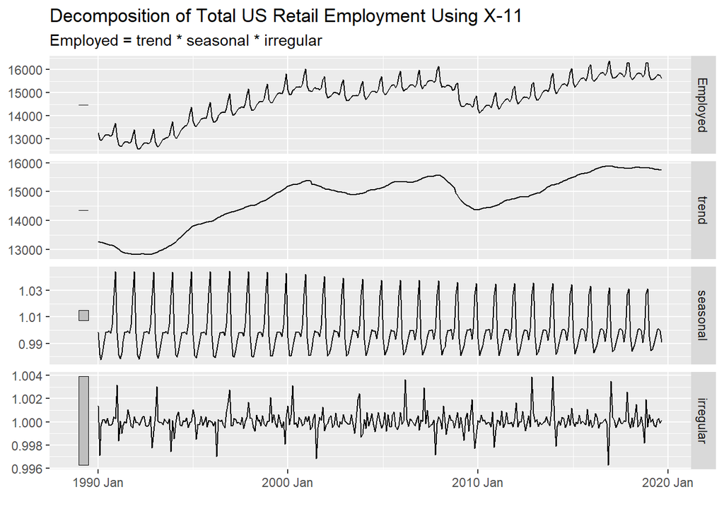

```r
x11_dcmp <- us_retail_employment %>%
  model(x11 = X_13ARIMA_SEATS(Employed ~ x11())) %>%
  components()

autoplot(x11_dcmp) +
  labs(x='', title='Decomposition of Total US Retail Employment Using X-11')
```

Above, the X-11 trend cycle captures the sudden fall due to the 2008 financial crisis better than STL or classical decomp.It can also be useful to employ seasonal sub-series plots of the seasonal component to help visualize the variation in the seasonal component over time. Here there are only small changes over time:

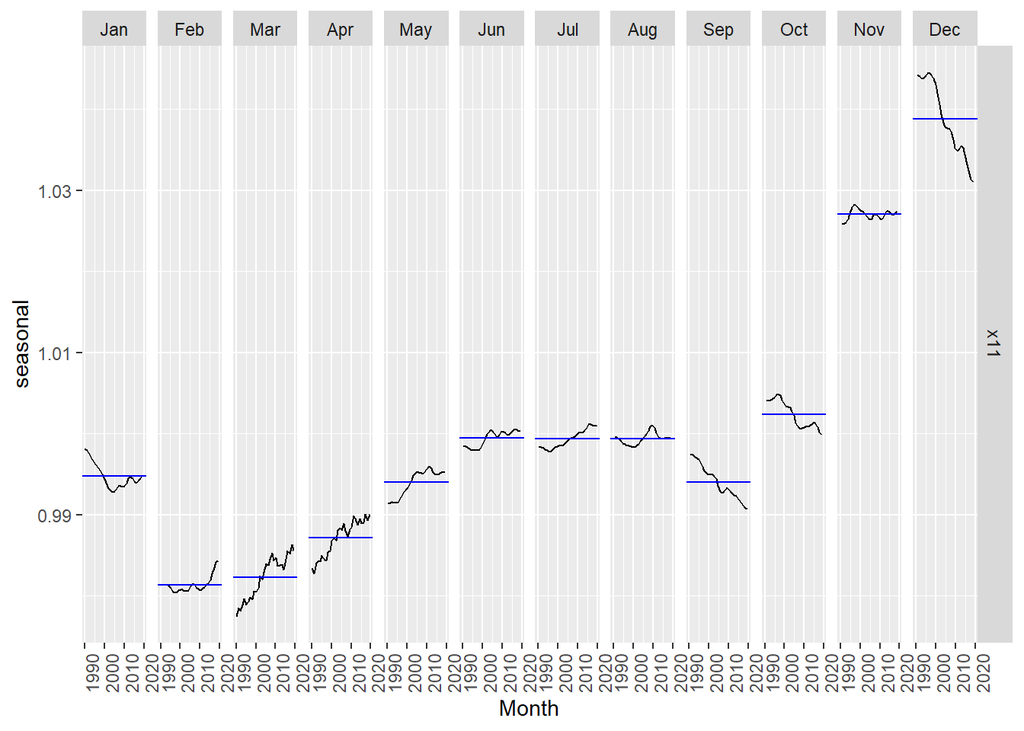

```r
x11_dcmp %>%
  gg_subseries(seasonal)
```

2. SEATS
   1. Stands for Seasonal Extraction ARIMA Time Series (Ch 9 covers ARIMA models)
   2. Developed by Bank of Spain
   3. too complicated to explain apparently

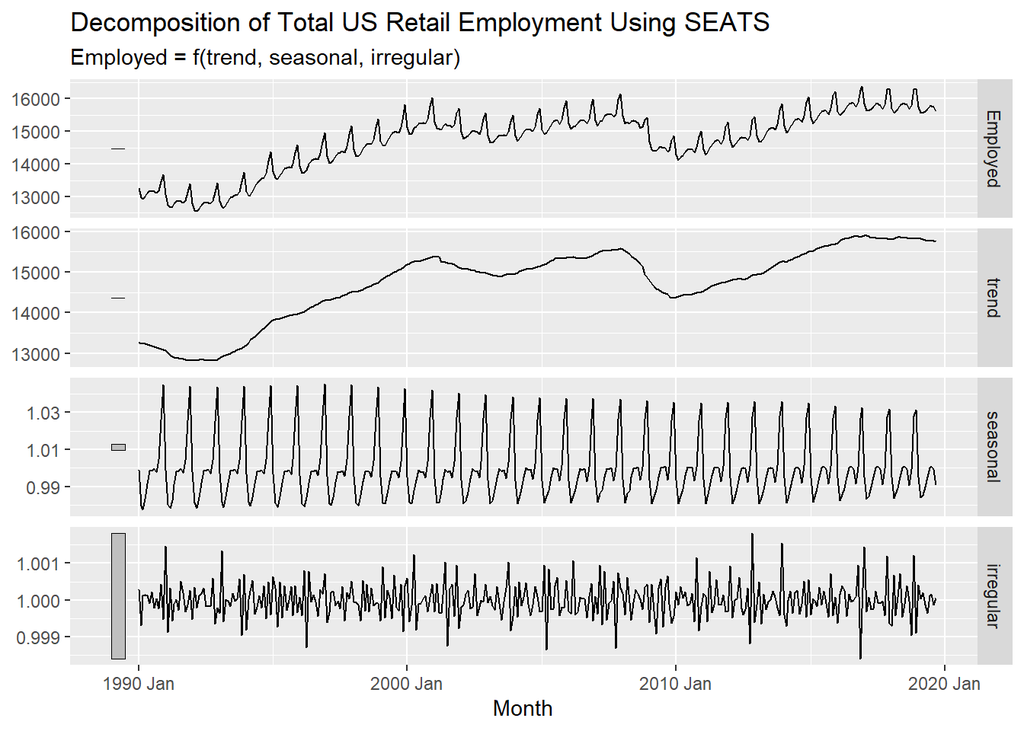

```r
seats_dcmp <- us_retail_employment %>%
  model(seats = X_13ARIMA_SEATS(Employed ~ seats())) %>%
  components()

autoplot(seats_dcmp) +
  labs(title = 'Decomposition of Total US Retail Employment Using SEATS')
```

Result is quite similar to X-11.

`X-13ARIMA_SEATS()` function calls the `seasonal` package which has many options for handling variations.

## 3.6 STL Decomposition

1. Stands for “Seasonal and Trend decomposition using Loess”
2. Has advantages over SEATS and X-11:
   1. handles any type of seasonality not just quarterly and yearly
   2. seasonal component may change over time, and rate of change controlled by user
   3. smoothness of trend-cycle can be controlled by user
   4. robust to outliers
3. Has disadvantages:
   1. does not handle trading day or calendar variation automatically
   2. can only be used for additive decomposition
      1. if multiplicative decomp is needed, take log of the data and then back-transform components
      2. any decomps between multiplicative and additive, use Box-Cox

**Example**

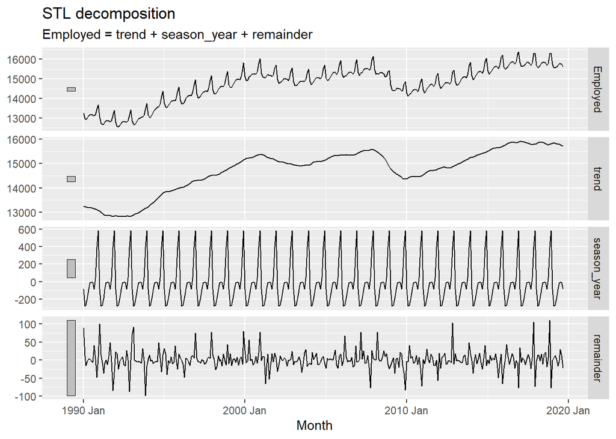

```r
us_retail_employment %>%
  model(STL(Employed ~ trend(window = 7) +
              season(window='periodic'),
            robust = TRUE)) %>%
  components() %>%
  autoplot()
```

The two main parameters for `STL()` are trend-cycle window `trend()` and seasonal window `seasona()`. Both should be odd numbers.